## Adaptive practice in online learning

#### Leiden University, Honours Class, Revolution of Learning in the Digital Age

#### Alexander Savi, 7 March 2017

### During what yearly festivity do Leidenaren celebrate the liberation from the Spaniards?

#### Leidens Ontzet

### Who painted "The Relief of Leiden", picturing the Leidens Ontzet?

#### Otto van Veen

### During which years did the siege take place?

#### 1573 - 1574

### In which century? Or during which war?

#### 16th century, Eighty Years' War

### During what yearly festivity do Leidenaren celebrate the liberation from the Spaniards? <font color="#D55E00">too easy?</font>

#### Leidens Ontzet

### Who painted "The Relief of Leiden", picturing the Leidens Ontzet? <font color="#D55E00">too hard?</font>

#### Otto van Veen

### During which years did the siege take place? <font color="#009E73">better?</font>

#### 1573 - 1574

### In which century? Or during which war? <font color="#009E73">better?</font>

#### 16th century, Eighty Years' War

[figure not shown]

### Adaptive practice

# <font color="#E69F00">Where?</font>

# <font color="#56B4E9">How?</font>

# <font color="#CC79A7">Why?</font>

## But first, hi!

#### Past

* UvA Psychology
* Honours Bachelor
* Research Master
* Psychological Methods
* Oefenweb

#### Present

* PhD candidate
* Online learning
* A/B tests
* Computerized adaptive practice
* Cognitive development
* Oefenweb / Coursera

Find out more, contact, and slides @ [alexandersavi.nl](http://www.alexandersavi.nl)

# <font color="#E69F00">Where?</font>

### An application for adaptive practice

## Oefenweb

[figure not shown]

Math Garden, Language Sea, Words&Birds, Stats Plant

±150.000 active users

±1.000.000 responses p/day

±1600 schools

±45000 items

[figure not shown]

Many domains (e.g., +, -, x, /, money, word problems)

Choose difficulty level

Collect coins

Question mark

Instructions

### Adaptive practice by Oefenweb (Dutch)

[video not shown]

# <font color="#56B4E9">How?</font>

### The technology for adaptive practice

# Difficulty?

# Ability?

# Elo rating system

### `$$ability_{p}=ability_{p}+K*\big(S-E\left(S\right)\big)$$`

### `$$difficulty_{i}=difficulty_{i}+K*\big(S-E\left(S\right)\big)$$`

where

`\(S\)` = observed score {0, 1}

`\(E\left(S\right)\)` = expected score, based elo-scores and measurement model

`\(K\)` = constant scaling factor (determines the influence of a win or loss)

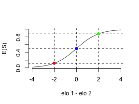

[interactive chart not shown]

.footnote[S. Klinkenberg, M. Straatemeier, H.L.J. van der Maas (2011). [Computer adaptive practice of Maths ability using a new item response model for on the fly ability and difficulty estimation](http://hvandermaas.socsci.uva.nl/Homepage_Han_van_der_Maas/Publications_files/papers/klinkenberg.pdf).]

# <font color="#56B4E9">How?</font>

### More opportunities for adaptive practice

## Multidimensional adaptivity

[figure not shown]

#### Instruction

[figure not shown]

#### Repetition

[figure not shown]

#### Misconceptions

[figure not shown]

#### And so on...

## Self-adaptivity

[figure not shown]

### A perk and a caveat: can increase engagement, but [do students know best?](https://theconversation.com/students-dont-know-whats-best-for-their-own-learning-33835)

# <font color="#CC79A7">Why?</font>

### The rationale for adaptive practice

## Personalization is key

Zone of proximal development

* 1920s Lev Vygotsky
* Developmental psychology

Scaffolding

* 1950s Jerome Bruner
* Cognitive psychology

2 sigma problem

* 1980s Benjamin Bloom
* Educational psychology

Deliberate practice

* 1990s Anders Ericsson
* Expertise

## Personalization is key

Zone of proximal development

[figure not shown]

Scaffolding

[figure not shown]

2 sigma problem

[figure not shown]

Deliberate practice

[figure not shown]

## Individual differences are huge

[figure not shown]

.footnote[M. Straatemeier, H.L.J. van der Maas, B. Jansen (2013). [Combining computerized adaptive practice and monitoring: The possibilities of self-organizing adaptive learning tools](http://www.iaea.info/documents/paper_5b92a6b7.pdf).]

## New venues for research

### Microgenetic method

.footnote[[M. J. S. Brinkhuis, A. O. Savi, F. Coomans, A. D. Hofman, H. L. J. van der Maas, G. & Maris. Learning as it happens: Advances in computerized adaptive practice.](http://www.alexandersavi.nl/publications/)]

### Formative / summative

## Monitoring versus testing

### A/Bonus

# <font color="#F0E442">A/B testing</font>

### Very short introduction to A/B tests in online learning

[figure not shown]

[Facebook](https://facebook.github.io/planout/), [Twitter](https://blog.twitter.com/2015/the-what-and-why-of-product-experimentation-at-twitter-0), [Wikipedia](https://www.mediawiki.org/wiki/Wikipedia.org_Portal_A/B_testing), [Etsy](https://apptimize.com/blog/2014/01/etsy-continuous-innovation-ab-testing/), [Netflix](http://techblog.netflix.com/2016/04/its-all-about-testing-netflix.html), [Tinder](http://tech.gotinder.com/smart-photos-2/), [OkCupid](https://blog.okcupid.com/index.php/we-experiment-on-human-beings/), ...

[Try this at home.](https://www.behave.org/tests-of-the-week/)

[figure not shown]

More on A/B testing in computerized adaptive practice environments and massive open online courses @ [alexandersavi.nl](http://www.alexandersavi.nl).

# A/B testing

# ⚔

# Adaptivity

## Multi-armed bandit

.footnote[[Tinder](http://tech.gotinder.com/smart-photos-2/) does it!]

### Ideally, a MOOC* would work like the GPS navigation device in your car. You tell it where you want to go, it figures out where you are, and it guides you along the most optimal route. Keeping with the analogy, current MOOCs are like having all GPS navigation devices instruct every car driver to turn right at 9:15 on Monday morning.

excerpt from [Navigating Massive Open Online Courses](http://science.sciencemag.org/content/347/6225/958.full)

.footnote[[*] Or any other (online) learning environment.]